# Colour and attraction report coursework

*N* removed NAs: 3

*N* removed typo: 1

*N* removed <18: 28

*N* total clean: 118

| Group | *N* | *M*<sub>age</sub> | *M*<sub>rating</sub> |
| --- | --- | --- | --- |
| Control | 56 | 20.3 | 6.38 |
| Experim | 62 | 20.7 | 5.66 |

**Main analysis results**

*t*(116) = 5.75, *p* < .001

[interactive chart not shown]

[figure not shown]

[interactive chart not shown]

# Colour and attraction report coursework

Analysing Data, Spring 2020, Candidate 218189

# Methods

## Participants

A total of 150 participants took part in the initial study. The following table displays the mean, standard deviation and range of the participants’ ages:

```
## # A tibble: 1 x 4
##    mean    sd   min   max
##   <dbl> <dbl> <dbl> <dbl>
## 1  20.5  1.84    18    27
```

A total of 32 participants were removed from the initial intake, this was due to the fact that some participants’ ages were considered unethical, those under the age of 18 being removed since they could not reliably give consent to participate, as well as ages that were typed incorrectly also being removed e.g. “1w” due to the fact they cannot be processed as numeric. Participants who did not give their age were also removed as they could have potentially been an age that was unethical to participate. Therefore, a total of 118 participants were included in the final results. The following table encapsulates descriptives about participants based on the experimental condition they were in:

```
## # A tibble: 2 x 4
##   CONDITION     n  mean    sd
##   <fct>     <int> <dbl> <dbl>
## 1 white        56  20.3  1.70
## 2 red          62  20.7  1.97
```

## Design

The conceptual hypothesis in this study was: Does colour influence attractiveness?

In terms of operationalisation of the key variables, the independent variable in this case was the colour which was being rated, which was operationalised through the background in which a black and white photo of a man was placed which was then presented to participants. The dependent variable in this case was ratings of attractiveness, this was compiled through three questions asked of the participants after they looked at the photo, in which participants gave their answers on a 9 point rating scale (mentioned later)

The experiment was conducted in a laboratory environment implementing an independent measures design. Participants viewed a black and white photo of a man on either a white (control condition) or red (experimental condition) background. Participants were then asked three questions relating to their perceived attractiveness of the man, these questions being:

- “How attractive do you think this person is?”
- “How pleasant is this person to look at?”
- “If I were to meet the person in this picture face to face, I would think he is attractive.”

Participants were asked to rate their responses on a scale of 1 to 9, 9 being the most positive response.

# Results

The general pattern of results is evident on the following plot:

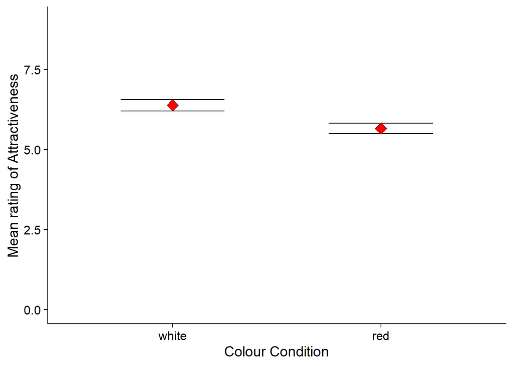

As displayed on the plot, the composite mean score for ratings of attractiveness in the control condition (the man on the white background) is 6.38, where the composite mean score for ratings of attractiveness in the experimental condition (the man on the red background) is 5.66, giving a difference of 0.72 and showing that participants found the person on the white background more attractive overall when asked their 3 questions. These composite means were obtained by gathering a cumulative score of each participants ratings of attractiveness on the three questions presented to them.

The statistical test in use in this case was a T test, to compare the mean ratings of attractiveness for the white condition and the red condition, in order to see if there is a significant difference and whether the data proves or disproves the hypothesis. The calculation of the T test was composed using code that compared the composite mean rating of attractiveness in the red and white conditions. The results of the T test are as follows:

```
##
##  Two Sample t-test
##
## data:  opinion_comp by CONDITION
## t = 6, df = 116, p-value = 0.00000007
## alternative hypothesis: true difference in means is not equal to 0
## 95 percent confidence interval:
##  0.475 0.975
## sample estimates:
## mean in group white   mean in group red
##                6.38                5.66
```

As you can see, the T score obtained is 5.75, with the degrees of freedom being 116 and the P-value being 7.437e-08. When looking at a table of critical values, with the idea that the obtained score must be equal to or exceed the critical value in order to be significant, I can state that the result obtained is significant.

# Discussion

In this study, the aim was to find whether colour has an impact on perceived male attractiveness, as well as to replicate experiment 1 from the original Elliot et al., 2010 study. When looking at the data gathered, the composite means and the results of the T test, it was found that there was a significant difference in attractiveness ratings of men presented on a white background compared to men presented on a red background, in that average ratings of attractiveness were higher overall in the white (control) condition, therefore disproving the original hypothesis that red would be the more attractive colour for males, disproving the hypothesis to the point where it was found that red wasn’t just considered as attractive as the control condition, but white was considered more attractive, implying that either red is considered actively less attractive than other colours, or that white is considered more attractive than other colours despite it being set as the control colour as it is neutral.

When comparing the results gathered to the results of the original Elliot (2010) study. In Elliot’s experiment 1, he found that participants rated men on a red background as significantly more attractive than men on a white background (an average rating of 6.79 for men on the red background and an average rating of 5.67 for men on a white background). These results contradict our results gathered in this replication as Elliot’s results strongly suppported the hypothesis where ours strongly disproved it. This could be for a variety of reasons, one potentially being that the samples were gathered from different cultures, with Elliot’s being an all American sample with ours being gathered in the UK, meaning there may be a cultural difference in colour attractiveness, particularly given that the ages of the samples are also similar.

However, when comparing my results to other studies, they are not so contradictory. In Hesslinger, Golbach and Carbon’s 2015 study, The purpose of their research was “to gain further insights concerning the robustness and the ecological validity of this red effect” this being the effect that Elliot found in his original study. Their first experiment was a close replication of Elliot’s as ours was, in that a photo of a young man was presnted on a red or white background, with participants being asked to rate their attractiveness. In their 2015 study, they did not find any significant impact of red in either of the studies they conducted. These studies also disprove my hypothesis and therefore support our findings. An effect these researchers did find however, was that apparel style can also impact attractiveness, with men wearing formal clothing rated as more attractive by participants than those who were not.

In regards to strengths and limitations of my study, one strength and weakness is the fact the research was conducted in a laboratory environment, allowing for the elimination of extraneous variables which raises the overall validity of the research, though to the same token, the fact the study is conducted in a controlled environment provides a lack of ecological validity. This lack of ecological validity in my study as well as in the original Elliot (2010) study, could mean the results are not generalisable to everyday life and that the effects of colour on attractiveness in a realistic setting are very different. As well as this, both this study as well as the original implemented an independent groups design, something that comes with its own set of pros and cons. One con of this design could be that the individual differences may play a part in the results as participants do not act as their own baseline as they would in a repeated measures design, since it does not allow for direct comparison of how participants rate the attractiveness of each colour since they only partake in one condition. However, this is also a strength since it prevents order effects that may be present in a repeated measures design.

Given that our results are contradictory to those of Elliot, it could be argued that there is no reason to research further into this phenomenon, however it may be interesting to research this area further and uncover why these results were different. Specifically, since the results were different and the only main factor that differentiated the procedures was the cultures the samples came from, it may be interesting to research further into the idea that culture can impact colour attractiveness. Also, since most studies in this research area study male attractiveness, meaning the samples are primarily female, it would also be interesting to see if there are any gender differences in this area, especially since biologially women see colours more vividly than men, potentially causing a difference in the way they process colours and which colours they are more likely to find attractive. As well as this, investigating colour attractiveness in animals could provide an insight as to whether colour attractiveness is something constructed by society or whether it is something more innate, since people may find red more attractive given connotations such as love associated with the colour.

To conclude, my main findings disprove the hypothesis in that red was not considered more attractive by participants, disproving the hypothesis to the extent that white was actually rated as more attractive by the participants, a finding that was very contradictory to Elliot’s original 2010 study. One main takeaway from this could be that methodologically, experiments into colour attractiveness such as these may be null and void due to the fact they were constructed in a lab environment, not replicating a real life situation effectively. As well as this, given that the results gathered here are contradictory to those in the original study, one takeaway could be that culture could have an impact on colour attractiveness, due to the fact that the only major factor differing the construction of these studies was the culture’s of the participants.

# References

Elliot, A. J., Niesta Kayser, D., Greitemeyer, T., Lichtenfeld, S., Gramzow, R. H., Maier, M. A., & Liu, H. (2010). Red, rank, and romance in women viewing men. *Journal of Experimental Psychology: General, 139*(3), 399.

Hesslinger, V. M., Goldbach, L., & Carbon, C. C. (2015). Men in red: A reexamination of the red-attractiveness effect. Psychonomic bulletin & review, 22(4), 1142-1148. *Journal of Experimental Psychology: General, 139*(3), 399.